# Interpolation

Peter Ralph

2017-12-20

# High-dimensional, noisy interpolation

## The model

Suppose that we have noisy observations of a function from $\mathbb{R}^k \to \mathbb{R}^n$, with $n \gg k$:
$$\begin{aligned}
(y_{i1}, \ldots, y_{in}) &= f(x_{i1}, \ldots, x_{ik}) + \epsilon_i \\
\epsilon_i \sim N(0, \Sigma) .
\end{aligned}$$

Then, given a new output value $\tilde y$, estimate the corresponding $\tilde x$.

## Test case

Let's take $k=1$ and let
$$\begin{aligned}
f(x) = (1/(1+x), 1/(1+x)^2, \ldots, 1/(1+x)^n)
\end{aligned}$$
for $0 \le x \le 1$. We will also take uncorrelated noise, $\Sigma = \sigma^2 I$.

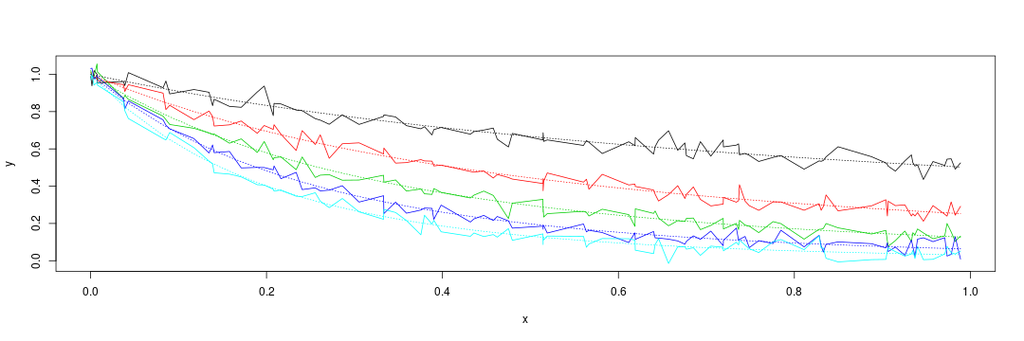

```r
n <- 5
nx <- 100
Sigma <- .001 * diag(n)
xx <- runif(nx)
f <- function (x) { sapply(1:n, function (u) { 1/(1+x)^u }) }
fnoise <- function (x) { f(x) + mvrnorm(NROW(x), mu=rep(0,n), Sigma=Sigma) }
yy <- fnoise(xx)
matplot(xx[order(xx)], yy[order(xx),], type='l',
        xlab='x', ylab='y', lty=1)
matlines(xx[order(xx)], f(xx[order(xx)]), lty=3)
```

## Local interpolation

A first guess is to take a weighted average over the reference values of $x$, weighted according to their proximity to the observed $y$. For instance,
$$\begin{aligned}
\tilde x &= \sum_i x_i
\frac{\exp\left(-\|\tilde y - y_i\|^2 / 2 \omega^2\right)}
{\sum_j \exp\left(-\|\tilde y - y_j\|^2 / 2 \omega^2\right)}
\end{aligned}$$
where $\omega$ is chosen appropriately.

```r
inverse_interpolation
```

```
## function (x, y, ypred, omega) {
##     y <- sweep(y, 2, omega, "/")
##     ypred <- sweep(ypred, 2, omega, "/")
##     dvec <- fields::rdist(y, ypred)
##     dvec <- sweep(dvec, 2, apply(dvec,2,min), "-")
##     w <- exp(-dvec^2)
##     wsums <- colSums(w)
##     if (any(wsums == 0)) {
##         warning("Bandwidth is too small -- some results will be NaN.")
##     }
##     w <- sweep(w, 2, wsums, "/")
##     xpred <- crossprod(w, x)
##     return(xpred)
## }
## <bytecode: 0x55fefc405f20>
## <environment: namespace:interposim>
```

Let's check this works, setting $\omega$ to include roughly 10% of the nearest points.

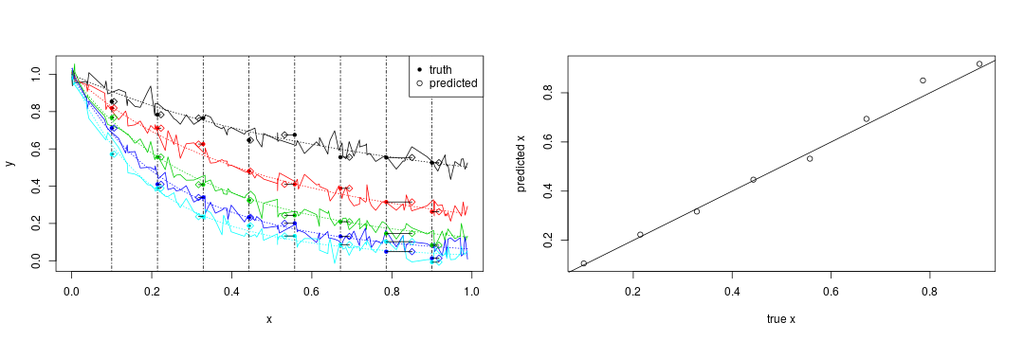

```r
xref <- seq(0.1,0.9, length.out=8)
yref <- fnoise(xref)
xpred <- inverse_interpolation(xx, yy, yref, omega=0.05)

layout(t(1:2))
matplot(xx[order(xx)], yy[order(xx),], type='l',
        xlab='x', ylab='y', lty=1)
matlines(xx[order(xx)], f(xx[order(xx)]), lty=3)
abline(v=xref, lty=4)
matpoints(xref, yref, pch=20)

matpoints(xpred, yref, pch=23)
segments(x0=xref, x1=xpred, y0=yref)
legend("topright", pch=c(20,1), legend=c("truth", "predicted"))

plot(xref, xpred, xlab='true x', ylab='predicted x')
abline(0,1)
```

### Error quantification

How well is this doing? Let's see.

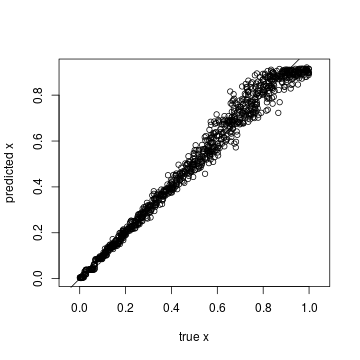

```r
ntest <- 1000
xref <- runif(ntest)
yref <- fnoise(xref)
xpred <- inverse_interpolation(xx, yy, yref, omega=0.05)
plot(xref, xpred, xlab='true x', ylab='predicted x', asp=1)
abline(0,1)
```

The error varies with the true $x$, which makes sense since the curves flatten as $x$ increases.

How does this depend on the number of training samples:

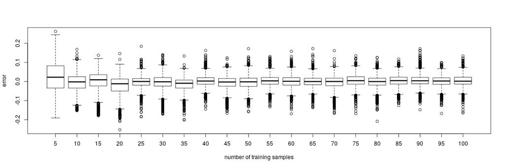

```r
ntest <- 1000
nvals <- 5*(1:20)
resid_list <- lapply(nvals, function (nx) {
                xx <- runif(nx)
                f <- function (x) { sapply(1:n, function (u) { 1/(1+x)^u }) }
                fnoise <- function (x) { f(x) + mvrnorm(NROW(x), mu=rep(0,n), Sigma=Sigma) }
                yy <- fnoise(xx)
                xref <- runif(ntest)
                yref <- fnoise(xref)
                xpred <- inverse_interpolation(xx, yy, yref, omega=0.05)
                return(xpred-xref)
            } )
names(resid_list) <- nvals
boxplot(resid_list, xlab='number of training samples', ylab='error')
```

## With correlation

Now let's see what happens if there is a lot of unmodeled correlation in the predictors. We'll also increase the number of predictors to 100, and suppose there are blocks of 50, 30, 10, 5, and 5 variables that are correlated with each other with $\rho=0.75$.

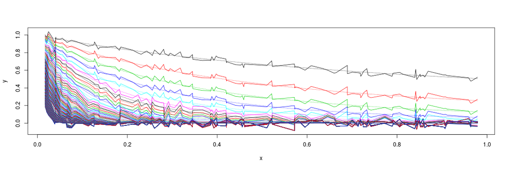

```r
n <- 100
var_blocks <- c(rep(1,5), rep(2,5), rep(3,10), rep(4,30), rep(5, 50))
rho <- 0.75
Sigma <- .001 * (rho * outer(var_blocks, var_blocks, "=="))
nx <- 100
xx <- sort(runif(nx))
f <- function (x) { sapply(1:n, function (u) { 1/(1+x)^u }) }
fnoise <- function (x) { f(x) + mvrnorm(NROW(x), mu=rep(0,n), Sigma=Sigma) }
yy <- fnoise(xx)
matplot(xx, yy, type='l',
        xlab='x', ylab='y', lty=1)
matlines(xx, f(xx), lty=3)
```

First let's check if we can get the covariance matrix from these data. We'll do this by subtracting off the running mean and then taking the usual covariance.

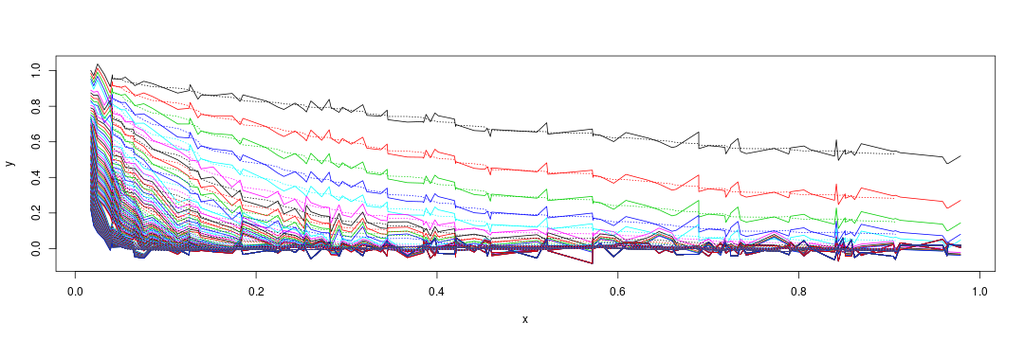

```r
win_halfwidth <- 5
win_width <- 2*win_halfwidth + 1
use_these <- ((1:nrow(yy)) > win_halfwidth) & ((1:nrow(yy)) <= nrow(yy)-win_halfwidth)
zz <- apply(yy, 2, cumsum)
zz <- (zz[-(1:(win_width-1)),] - rbind(0,zz)[-((nrow(zz)-win_width+2):(nrow(zz)+1)),]) / win_width
est_cov <- cov(yy[use_these,] - zz)

matplot(xx, yy, type='l',
        xlab='x', ylab='y', lty=1)
matlines(xx[use_these], zz, lty=3)
```

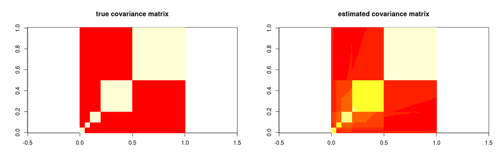

```r
layout(t(1:2))
image(Sigma, asp=1, main='true covariance matrix')
image(est_cov, asp=1, main='estimated covariance matrix')
```

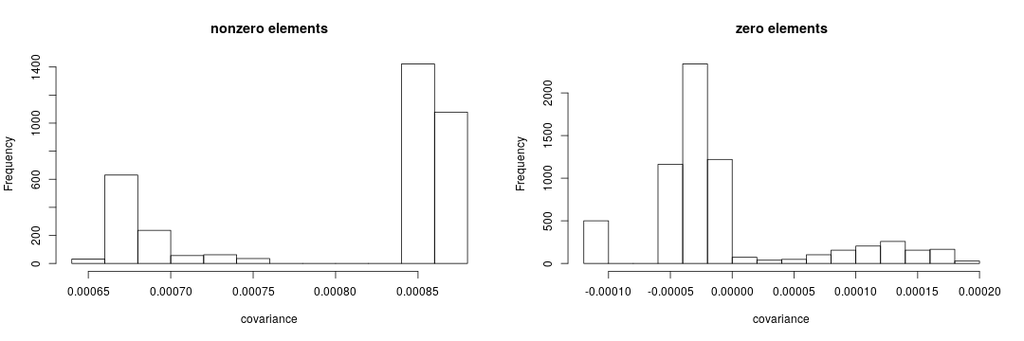

```r
hist(est_cov[Sigma>0], xlab='covariance', main='nonzero elements')
hist(est_cov[Sigma==0], xlab='covariance', main='zero elements')
```

Now let's see how well this does despite this unmodeled correlation.

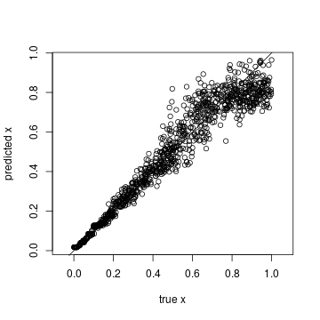

```r
ntest <- 1000
xref <- runif(ntest)
yref <- fnoise(xref)
xpred <- inverse_interpolation(xx, yy, yref, omega=0.05)
plot(xref, xpred, xlab='true x', ylab='predicted x', asp=1)
abline(0,1)
```

How does this depend on the bandwidth?

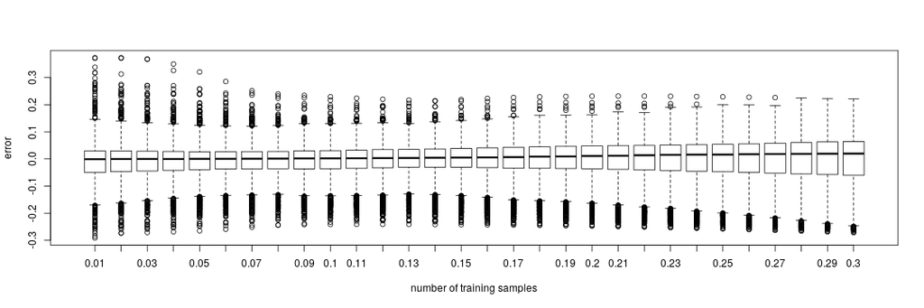

```r
ntest <- 1000
omega_vals <- (1:30)/100
resid_list <- lapply(omega_vals, function (omega) {
                xpred <- inverse_interpolation(xx, yy, yref, omega=omega)
                return(xpred-xref)
            } )
names(resid_list) <- omega_vals
boxplot(resid_list, xlab='number of training samples', ylab='error')
```

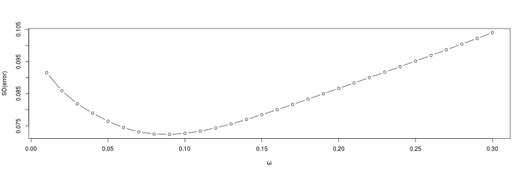

```r
plot(omega_vals, sapply(resid_list, sd),
        xlab=expression(omega), ylab="SD(error)", type='b')
```